# Create TMB barplots of tumors across multiple timepoints of the PBTA Cohort

Antonia Chroni chronia@chop.edu for D3B

2023

### Data used

In this notebook, we are using the `tmb_genomic.tsv` file generated from the `01-preprocess-data.Rmd` script.

# Set up

```r
suppressPackageStartupMessages({
  library(tidyverse)
})
```

# Directories and File Inputs/Outputs

```r
# Detect the ".git" folder. This will be in the project root directory.
# Use this as the root directory to ensure proper sourcing of functions
# no matter where this is called from.
root_dir <- rprojroot::find_root(rprojroot::has_dir(".git"))
scratch_dir <- file.path(root_dir, "scratch")
analysis_dir <- file.path(root_dir, "analyses", "tmb-vaf-longitudinal")
input_dir <- file.path(analysis_dir, "input")

# Input files
tmb_genomic_file <- file.path(scratch_dir, "tmb_genomic.tsv")
tumor_descriptor_color_palette_file <- file.path(root_dir, "figures", "palettes", "tumor_descriptor_color_palette.tsv")

# File path to plots directory
plots_dir <-
  file.path(analysis_dir, "plots-v3")
if (!dir.exists(plots_dir)) {
  dir.create(plots_dir)
}

source(paste0(analysis_dir, "/util/function-create-barplot-v3.R"))
source(paste0(root_dir, "/figures/scripts/theme.R"))
```

# Read in data and process

```r
# Read and process tmb_genomic file
tmb_genomic_all <- readr::read_tsv(tmb_genomic_file, guess_max = 100000, show_col_types = FALSE)

# Are there any samples with both WGS and WXS?
tmb_genomic_all %>%
  unique() %>%
  arrange(Kids_First_Participant_ID, experimental_strategy)  %>%
  group_by(Kids_First_Participant_ID) %>%
  dplyr::summarise(experimental_strategy_sum = str_c(experimental_strategy, collapse = ";"))
```

| Kids_First_Participant_ID | experimental_strategy_sum |
| --- | --- |
| PT_00G007DM | WGS;WGS |
| PT_02J5CWN5 | WGS;WGS |
| PT_1H2REHT2 | WGS;WGS;WGS |
| PT_1ZAWNGWT | WGS;WGS |
| PT_25Z2NX27 | WGS;WGS |
| PT_2ECVKTTQ | WGS;WGS |
| PT_2FVTD0WR | WGS;WGS |
| PT_2YT37G8P | WGS;WGS |
| PT_37B5JRP1 | WGS;WGS |
| PT_3CHB9PK5 | WGS;WGS |

[output cut: 51 more lines]

```r
# Yes, they are, so let's remove these from downstream analyses.
tmb_genomic <- tmb_genomic_all %>%
  filter(!experimental_strategy == "WXS") %>%
  mutate(tumor_descriptor_order = case_when(grepl("Diagnosis", tumor_descriptor) ~ "1",
                                          grepl("Recurrence", tumor_descriptor) ~ "2",
                                          grepl("Progressive", tumor_descriptor) ~ "3",
                                          grepl("Deceased", tumor_descriptor) ~ "4",
                                          grepl("Second Malignancy", tumor_descriptor) ~ "5",
                                          grepl("Unavailable", tumor_descriptor) ~ "6"),
         patient_id = paste(short_histology, Kids_First_Participant_ID, sep = "_")) %>%
  arrange(tumor_descriptor_order, descriptors) %>%
 # create plot order by tumor_descriptor and descriptors
  mutate(plot_order = row_number())

# Read color palette
tumor_descriptor_color_palette <- readr::read_tsv(tumor_descriptor_color_palette_file, guess_max = 100000, show_col_types = FALSE)
```

# TMB per Patient case

We will explore TMB per `Kids_First_Participant_ID` over time by creating stacked barplots.

```r
# Define parameters for function
ylim <- 360
tmb_df <- tmb_genomic

# Run function
fname <- paste0(plots_dir, "/", "TMB-genomic.pdf")
print(fname)
```

```
[1] "/Users/chronia/CHOP/GitHub/pbta-tumor-evolution/analyses/tmb-vaf-longitudinal/plots-v3/TMB-genomic.pdf"
```

```r
p <- create_stacked_barplot(tmb_df = tmb_df, ylim = ylim)
pdf(file = fname, width = 15, height = 6)
```

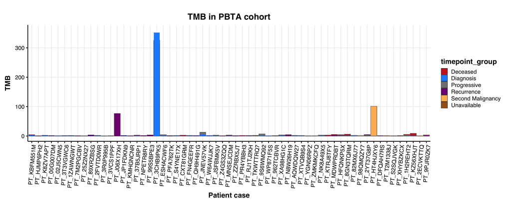

```r
print(p)
dev.off()
```

Attention: Low TMB defined as ≤5 mutations/Mb, intermediate TMB defined as >5 and ≤20/Mb, high TMB defined as >20 and ≤50 Mb, and very high TMB defined as >50 mutations/Mb.

Here, we notice that there are samples with high TMB (hyper-mutant samples). Next, we will exclude these samples (threshold >= 50) from downstream analysis. Attention is needed in cases with high number of mutations in only one timepoint as this will lead to un-matched longitudinal samples. We will also remove those so we always have matched longitudinal samples.

```r
# Filter df
tmb_genomic_filter <- tmb_genomic %>%
  filter(!tmb >= 50)  %>%
  unique() %>%
  arrange(Kids_First_Participant_ID, tumor_descriptor) %>%
  group_by(Kids_First_Participant_ID) %>%
  dplyr::summarise(tumor_descriptor_sum = str_c(tumor_descriptor, collapse = ";")) %>%
  filter(!tumor_descriptor_sum %in% c("Diagnosis", "Progressive", "Recurrence")) %>%
  dplyr::left_join(tmb_genomic, by = c("Kids_First_Participant_ID", "tumor_descriptor_sum")) %>%
  mutate(cancer_group_sum = ifelse(short_histology == "HGAT", "High-grade glioma",
                                   ifelse(short_histology == "LGAT", "Low-grade glioma", "Other cancer group")),
         cancer_group_sum = replace_na(cancer_group_sum, "Other")) %>%
  drop_na(tmb) %>%
  arrange(tumor_descriptor_order, descriptors) %>%
 # create plot order by tumor_descriptor and descriptors
  mutate(plot_order = row_number())


# Define parameters for function
ylim <- 12.5
tmb_df <- tmb_genomic_filter

# Run function
fname <- paste0(plots_dir, "/", "TMB-genomic-no-hypermutants.pdf")
print(fname)
```

```
[1] "/Users/chronia/CHOP/GitHub/pbta-tumor-evolution/analyses/tmb-vaf-longitudinal/plots-v3/TMB-genomic-no-hypermutants.pdf"
```

```r
p <- create_stacked_barplot(tmb_df = tmb_df, ylim = ylim)
pdf(file = fname, width = 25, height = 8)
```

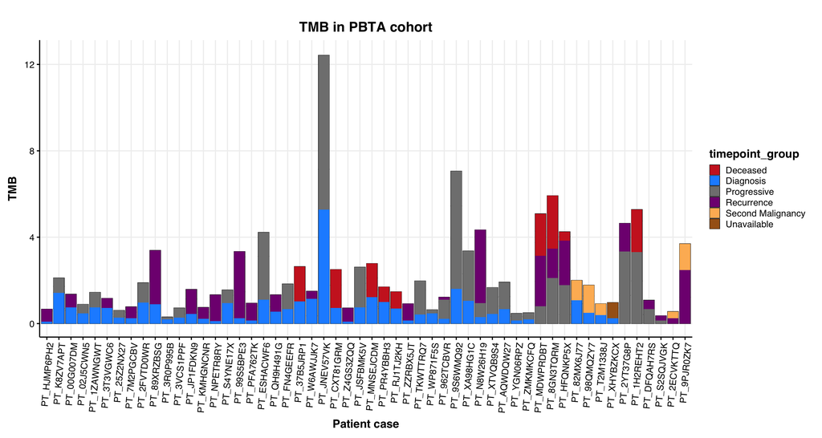

```r
print(p)
dev.off()
```

# TMB per Patient case and Cancer type

We will explore TMB per cancer group over time by creating stacked barplots. We will plot based on cancer groups presenting with the highest number of samples (High- and Low-grade gliomas) vesrus any other cancer groups.

```r
cancer_groups <- unique(as.character(tmb_genomic_filter$cancer_group_sum))
cancer_groups <- sort(cancer_groups, decreasing = FALSE)
print(cancer_groups)
```

```
[1] "High-grade glioma"  "Low-grade glioma"   "Other cancer group"
```

```
[1] 1
[1] "High-grade glioma"
[1] "/Users/chronia/CHOP/GitHub/pbta-tumor-evolution/analyses/tmb-vaf-longitudinal/plots-v3/TMB-genomic-High-grade glioma.pdf"
[1] 2
[1] "Low-grade glioma"
[1] "/Users/chronia/CHOP/GitHub/pbta-tumor-evolution/analyses/tmb-vaf-longitudinal/plots-v3/TMB-genomic-Low-grade glioma.pdf"
[1] 3
[1] "Other cancer group"
[1] "/Users/chronia/CHOP/GitHub/pbta-tumor-evolution/analyses/tmb-vaf-longitudinal/plots-v3/TMB-genomic-Other cancer group.pdf"
```

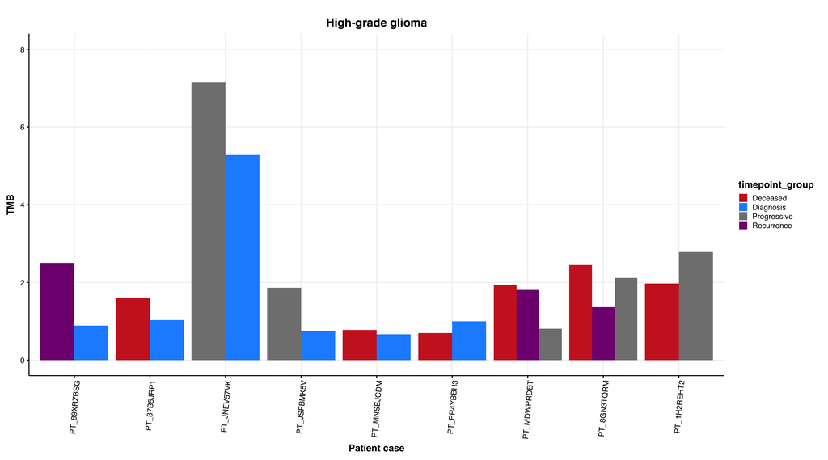

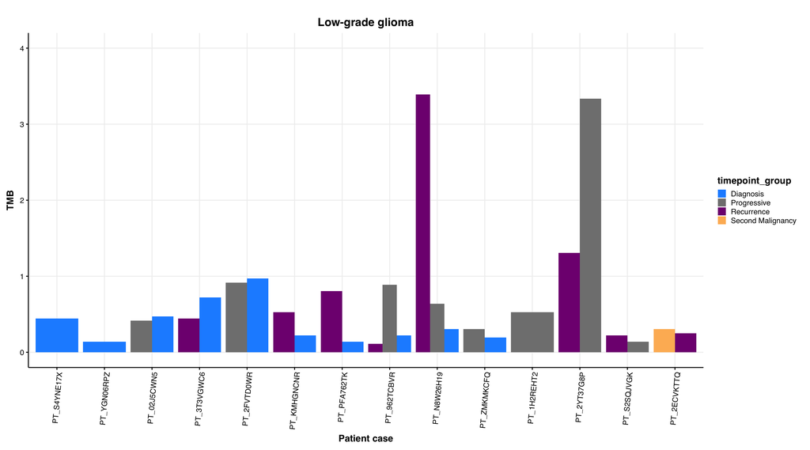

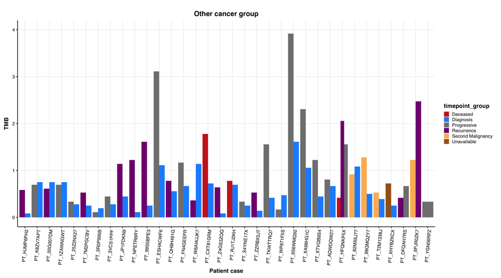

```r
for (i in seq_along(cancer_groups)) {
  print(i)
  tmb_genomic_filter_sub <- tmb_genomic_filter %>%
    filter(cancer_group_sum == cancer_groups [i])

  if (i == 1) {
    print(cancer_groups [i])
    # Define parameters for function
    ylim <- 8
    } else if (i == 2) {
      print(cancer_groups [i])
      # Define parameters for function
      ylim <- 4
      } else {
        print(cancer_groups [i])
        # Define parameters for function
        ylim <- 4
      }

    # Name plots
    fname <- paste0(plots_dir, "/", "TMB-genomic", "-", cancer_groups[i], ".pdf")
    print(fname)

    # Run function
    p <- create_barplot_ct(tmb_df = tmb_genomic_filter_sub,
                                 ylim = ylim,
                                 ct_id = cancer_groups[i])
    pdf(file = fname, width = 18, height = 10)
    print(p)
    dev.off()

}
```

# Number of mutations per Patient case and biospecimen sample

Here, we want to explore the number of mutations (`mutation_count` column) per timepoint and biospecimen sample per patient case by creating barplots.

```r
tmb_genomic_filter_samples <- tmb_genomic_filter %>%
  arrange(tumor_descriptor_order, Kids_First_Biospecimen_ID) %>%
 # create plot order
  mutate(plot_order = row_number())

samples <- unique(as.character(tmb_genomic_filter_samples$Kids_First_Participant_ID))
print(samples)

for (i in seq_along(samples)) {
  print(i)
  tmb_sub <- tmb_genomic_filter_samples %>%
    filter(Kids_First_Participant_ID == samples[i])

  if (i %in% c(42, 37, 16, 1, 38, 52)) { # "PT_9S6WMQ92", "PT_ESHACWF6", "PT_JNEV57VK", "PT_TKWTTRQ7",  "PT_N8W26H19", "PT_2YT37G8P"
    print(samples[i])
    # Define parameters for function
    ylim <- 260
    } else if (i %in% c(27, 31, 30, 6, 38, 28,  15, 49, 47, 46, 50, 54)) {
      print(samples[i])
      # Define parameters for function
      ylim <- 100 # "PT_37B5JRP1", "PT_CXT81GRM", "PT_JSFBMK5V", "PT_XA98HG1C", "PT_N8W26H19",  "PT_89XRZBSG","PT_99S5BPE3", "PT_8GN3TQRM", "PT_HFQNKP5X", "PT_MDWPRDBT",  "PT_9PJR0ZK7", "PT_1H2REHT2"
      } else {
        print(samples[i])
        # Define parameters for function
        ylim <- 50
      }

  # Run function
  fname <- paste0(plots_dir, "/", samples[i], "-TMB-barplot.pdf")
  print(fname)
  p <- create_barplot_sample(tmb_df = tmb_sub,
                             ylim = ylim,
                             sid = samples[i])
  pdf(file = fname, width = 5, height = 4)
  print(p)
  dev.off()
}
```

[output not shown]